# Return Home

[View Code on Github](https://github.com/JohnKimaiyo/Business-Analytics-Power-BI/blob/main/Projects/Webscraping%20Projects/Top%20Female%20POP%20Music%20Artist%20YouTube%20Channels.ipynb)

# Top Female Pop Music Artists Youtube Channels EDA

## 1 Beyonce

Beyoncé Giselle Knowles-Carter is an American singer, songwriter and businesswoman. Dubbed as "Queen Bey" and a prominent cultural figure of the 21st century, she has been recognized for her artistry and performances, with Rolling Stone naming her one of the greatest vocalists of all time.

## 2 Rihana

Robyn Rihanna Fenty is a Barbadian singer, businesswoman, actress, and songwriter. She is widely regarded as one of the most prominent singers of the 21st century.

## 3 Shakira

Shakira Isabel Mebarak Ripoll, known mononymously as Shakira, is a Colombian singer and songwriter. Born and raised in Barranquilla, she has been referred to as the "Queen of Latin Music" and has been praised for her musical versatility.

## 4 Ciara

Ciara Princess Wilson is an American singer, songwriter, businesswoman, dancer, model, and actress. She rose to prominence with her debut studio album Goodies. The album spawned the single of the same name which topped the Billboard Hot 100 and the UK Singles Chart

## 5 Megan Stallion

Megan Jovon Ruth Pete, known professionally as Megan Thee Stallion, is an American rapper. Originally from Houston, Texas, she first garnered attention when videos of her freestyling became popular on social media platforms such as Instagram

## 6 Jeniffer Lopez

Jennifer Lynn Affleck, known by her maiden name and also shortened to J.Lo, is an American singer and actress. Often considered a pop culture icon, Lopez is one of the most influential entertainers in the world, credited for helping propel the Latin pop movement in American music.

```python
# lets import libraries
from googleapiclient.discovery import build
import pandas as pd
import seaborn as sns
import matplotlib.pyplot as plt
```

## 1 Beyonce

```python
#  Function to get   Beyonce Youtube channel statistics

api_key = 'AIzaSyB24Kop04L1GlTgRCm1XtQ4KB2a4gaBOwA'
Beyonce_channel_id = ['UCuHzBCaKmtaLcRAOoazhCPA' #  Beyonce

              ]
youtube = build('youtube','v3',developerKey = api_key)

from googleapiclient.errors import HttpError

def get_channel_stats(youtube, Beyonce_channel_id):
    all_data = []
    try:
        request = youtube.channels().list(
            part='snippet,contentDetails,statistics',
            id=','.join(Beyonce_channel_id)
        )
        response = request.execute()

        for item in response.get('items', []):
            snippet = item.get('snippet', {})
            statistics = item.get('statistics', {})

            data = {
                'Channel_name': snippet.get('title', ''),
                'Subscribers': statistics.get('subscriberCount', ''),
                'Views': statistics.get('viewCount', ''),
                'Total_videos': statistics.get('videoCount', '')
            }

            all_data.append(data)

    except HttpError as e:
        print(f"HTTP error occurred: {e}")
        print(f"Request URL: {e.resp.request.url}")
        print(f"Request body: {e.resp.request.body}")

    return all_data
```

```python
get_channel_stats(youtube,Beyonce_channel_id)
```

```
[{'Channel_name': 'Beyoncé',
  'Subscribers': '26600000',
  'Views': '18021652519',
  'Total_videos': '245'}]
```

```python
channel_statistics = get_channel_stats(youtube,Beyonce_channel_id )
```

```python
Beyonce_channel_data =pd.DataFrame(channel_statistics)
```

```python
Beyonce_channel_data
```

|  | Channel_name | Subscribers | Views | Total_videos |
| --- | --- | --- | --- | --- |
| 0 | Beyoncé | 26600000 | 18021652519 | 245 |

## 2 Rihanna

```python
#  Function to get Rihanna  in Youtube channel statistics

api_key = 'AIzaSyB24Kop04L1GlTgRCm1XtQ4KB2a4gaBOwA'
Rihanna_channel_id = ['UCcgqSM4YEo5vVQpqwN-MaNw' # Rihanna

              ]
youtube = build('youtube','v3',developerKey = api_key)



def get_channel_stats(youtube, Rihanna_channel_id):
    all_data = []
    try:
        request = youtube.channels().list(
            part='snippet,contentDetails,statistics',
            id=','.join(Rihanna_channel_id)
        )
        response = request.execute()

        for item in response.get('items', []):
            snippet = item.get('snippet', {})
            statistics = item.get('statistics', {})

            data = {
                'Channel_name': snippet.get('title', ''),
                'Subscribers': statistics.get('subscriberCount', ''),
                'Views': statistics.get('viewCount', ''),
                'Total_videos': statistics.get('videoCount', '')
            }

            all_data.append(data)

    except HttpError as e:
        print(f"HTTP error occurred: {e}")
        print(f"Request URL: {e.resp.request.url}")
        print(f"Request body: {e.resp.request.body}")

    return all_data
```

```python
get_channel_stats(youtube,Rihanna_channel_id)
```

```
[{'Channel_name': 'Rihanna',
  'Subscribers': '42600000',
  'Views': '23606574806',
  'Total_videos': '85'}]
```

```python
channel_statistics = get_channel_stats(youtube,Rihanna_channel_id )
```

```python
Rihanna_channel_data =pd.DataFrame(channel_statistics)
```

```python
Rihanna_channel_data
```

|  | Channel_name | Subscribers | Views | Total_videos |
| --- | --- | --- | --- | --- |
| 0 | Rihanna | 42600000 | 23606574806 | 85 |

## 3 Shakira

```python
#  Function to get  Shakira Youtube channel statistics

api_key = 'AIzaSyB24Kop04L1GlTgRCm1XtQ4KB2a4gaBOwA'
Shakira_channel_id = ['UCYLNGLIzMhRTi6ZOLjAPSmw' # Shakira

              ]
youtube = build('youtube','v3',developerKey = api_key)

from googleapiclient.errors import HttpError

def get_channel_stats(youtube, Shakira_channel_id):
    all_data = []
    try:
        request = youtube.channels().list(
            part='snippet,contentDetails,statistics',
            id=','.join(Shakira_channel_id)
        )
        response = request.execute()

        for item in response.get('items', []):
            snippet = item.get('snippet', {})
            statistics = item.get('statistics', {})

            data = {
                'Channel_name': snippet.get('title', ''),
                'Subscribers': statistics.get('subscriberCount', ''),
                'Views': statistics.get('viewCount', ''),
                'Total_videos': statistics.get('videoCount', '')
            }

            all_data.append(data)

    except HttpError as e:
        print(f"HTTP error occurred: {e}")
        print(f"Request URL: {e.resp.request.url}")
        print(f"Request body: {e.resp.request.body}")

    return all_data
```

```python
get_channel_stats(youtube,Shakira_channel_id )
```

```
[{'Channel_name': 'Shakira',
  'Subscribers': '45400000',
  'Views': '29153079577',
  'Total_videos': '342'}]
```

```python
channel_statistics = get_channel_stats(youtube,Shakira_channel_id  )
```

```python
Shakira_channel_data =pd.DataFrame(channel_statistics)
```

```python
Shakira_channel_data
```

|  | Channel_name | Subscribers | Views | Total_videos |
| --- | --- | --- | --- | --- |
| 0 | Shakira | 45400000 | 29153079577 | 342 |

## 4 Ciara

```python
#  Function to get Ciara Youtube channel statistics

api_key = 'AIzaSyB24Kop04L1GlTgRCm1XtQ4KB2a4gaBOwA'
Ciara_channel_id = ['UClc5Eis2-L2JCcN62jmD21w' # Ciara

              ]
youtube = build('youtube','v3',developerKey = api_key)

from googleapiclient.errors import HttpError

def get_channel_stats(youtube, Ciara_channel_id):
    all_data = []
    try:
        request = youtube.channels().list(
            part='snippet,contentDetails,statistics',
            id=','.join(Ciara_channel_id)
        )
        response = request.execute()

        for item in response.get('items', []):
            snippet = item.get('snippet', {})
            statistics = item.get('statistics', {})

            data = {
                'Channel_name': snippet.get('title', ''),
                'Subscribers': statistics.get('subscriberCount', ''),
                'Views': statistics.get('viewCount', ''),
                'Total_videos': statistics.get('videoCount', '')
            }

            all_data.append(data)

    except HttpError as e:
        print(f"HTTP error occurred: {e}")
        print(f"Request URL: {e.resp.request.url}")
        print(f"Request body: {e.resp.request.body}")

    return all_data
```

```python
get_channel_stats(youtube,Ciara_channel_id)
```

```
[{'Channel_name': 'Ciara',
  'Subscribers': '5760000',
  'Views': '3594425762',
  'Total_videos': '217'}]
```

```python
channel_statistics = get_channel_stats(youtube,Ciara_channel_id)
```

```python
Ciara_channel_data =pd.DataFrame(channel_statistics)
```

```python
Ciara_channel_data
```

|  | Channel_name | Subscribers | Views | Total_videos |
| --- | --- | --- | --- | --- |
| 0 | Ciara | 5760000 | 3594425762 | 217 |

## 5 Megan Stallion

```python
#  Function to get  Megan Stallion Youtube channel statistics

api_key = 'AIzaSyB24Kop04L1GlTgRCm1XtQ4KB2a4gaBOwA'
Megan_Stallion_channel_id = ['UCKrdjiuS66yXOdEZ_cOD_TA' # Megan Stallion

              ]
youtube = build('youtube','v3',developerKey = api_key)

from googleapiclient.errors import HttpError

def get_channel_stats(youtube, Megan_Stallion_channel_id):
    all_data = []
    try:
        request = youtube.channels().list(
            part='snippet,contentDetails,statistics',
            id=','.join(Megan_Stallion_channel_id)
        )
        response = request.execute()

        for item in response.get('items', []):
            snippet = item.get('snippet', {})
            statistics = item.get('statistics', {})

            data = {
                'Channel_name': snippet.get('title', ''),
                'Subscribers': statistics.get('subscriberCount', ''),
                'Views': statistics.get('viewCount', ''),
                'Total_videos': statistics.get('videoCount', '')
            }

            all_data.append(data)

    except HttpError as e:
        print(f"HTTP error occurred: {e}")
        print(f"Request URL: {e.resp.request.url}")
        print(f"Request body: {e.resp.request.body}")

    return all_data
```

```python
get_channel_stats(youtube,Megan_Stallion_channel_id)
```

```
[{'Channel_name': 'Megan Thee Stallion',
  'Subscribers': '5860000',
  'Views': '2640609521',
  'Total_videos': '245'}]
```

```python
channel_statistics = get_channel_stats(youtube,Megan_Stallion_channel_id )
```

```python
Megan_Stallion_channel_data =pd.DataFrame(channel_statistics)
```

```python
Megan_Stallion_channel_data
```

|  | Channel_name | Subscribers | Views | Total_videos |
| --- | --- | --- | --- | --- |
| 0 | Megan Thee Stallion | 5860000 | 2640609521 | 245 |

## 6 Jeniffer Lopez

```python
#  Function to get  Jeniffer Lopez Youtube channel statistics

api_key = 'AIzaSyB24Kop04L1GlTgRCm1XtQ4KB2a4gaBOwA'
Jeniffer_Lopez_channel_id = ['UCr8RjWUQ_9KYcIPmWiqBroQ' # Jeniffer Lopez

              ]
youtube = build('youtube','v3',developerKey = api_key)

from googleapiclient.errors import HttpError

def get_channel_stats(youtube, Jeniffer_Lopez_channel_id):
    all_data = []
    try:
        request = youtube.channels().list(
            part='snippet,contentDetails,statistics',
            id=','.join(Jeniffer_Lopez_channel_id)
        )
        response = request.execute()

        for item in response.get('items', []):
            snippet = item.get('snippet', {})
            statistics = item.get('statistics', {})

            data = {
                'Channel_name': snippet.get('title', ''),
                'Subscribers': statistics.get('subscriberCount', ''),
                'Views': statistics.get('viewCount', ''),
                'Total_videos': statistics.get('videoCount', '')
            }

            all_data.append(data)

    except HttpError as e:
        print(f"HTTP error occurred: {e}")
        print(f"Request URL: {e.resp.request.url}")
        print(f"Request body: {e.resp.request.body}")

    return all_data
```

```python
get_channel_stats(youtube,Jeniffer_Lopez_channel_id)
```

```
[{'Channel_name': 'Jennifer Lopez',
  'Subscribers': '16500000',
  'Views': '10579401741',
  'Total_videos': '301'}]
```

```python
channel_statistics = get_channel_stats(youtube,Jeniffer_Lopez_channel_id )
```

```python
Jeniffer_Lopez_channel_data =pd.DataFrame(channel_statistics)
```

```python
Jeniffer_Lopez_channel_data
```

|  | Channel_name | Subscribers | Views | Total_videos |
| --- | --- | --- | --- | --- |
| 0 | Jennifer Lopez | 16500000 | 10579401741 | 301 |

```python
# Combine DataFrames using concat
combined_female_pop_artist_channels_df = pd.concat([
                                    Beyonce_channel_data,
                                    Rihanna_channel_data ,
                                        Shakira_channel_data,

                                        Ciara_channel_data,
                                        Megan_Stallion_channel_data,
                                        Jeniffer_Lopez_channel_data,
                                      ], ignore_index=True)

# Display the result
print(combined_female_pop_artist_channels_df)
```

```
          Channel_name Subscribers        Views Total_videos
0              Beyoncé    26600000  18021652519          245
1              Rihanna    42600000  23606574806           85
2              Shakira    45400000  29153079577          342
3                Ciara     5760000   3594425762          217
4  Megan Thee Stallion     5860000   2640609521          245
5       Jennifer Lopez    16500000  10579401741          301
```

```python
combined_female_pop_artist_channels_df.info()
```

```
<class 'pandas.core.frame.DataFrame'>
RangeIndex: 6 entries, 0 to 5
Data columns (total 4 columns):
 #   Column        Non-Null Count  Dtype
---  ------        --------------  -----
 0   Channel_name  6 non-null      object
 1   Subscribers   6 non-null      object
 2   Views         6 non-null      object
 3   Total_videos  6 non-null      object
dtypes: object(4)
memory usage: 324.0+ bytes
```

```python
combined_female_pop_artist_channels_df['Subscribers'] = pd.to_numeric(combined_female_pop_artist_channels_df['Subscribers'])
combined_female_pop_artist_channels_df['Views'] = pd.to_numeric(combined_female_pop_artist_channels_df['Views'])
combined_female_pop_artist_channels_df['Total_videos'] = pd.to_numeric(combined_female_pop_artist_channels_df['Total_videos'])

combined_female_pop_artist_channels_df.info
```

```
<bound method DataFrame.info of           Channel_name  Subscribers        Views  Total_videos
0              Beyoncé     26600000  18021652519           245
1              Rihanna     42600000  23606574806            85
2              Shakira     45400000  29153079577           342
3                Ciara      5760000   3594425762           217
4  Megan Thee Stallion      5860000   2640609521           245
5       Jennifer Lopez     16500000  10579401741           301>
```

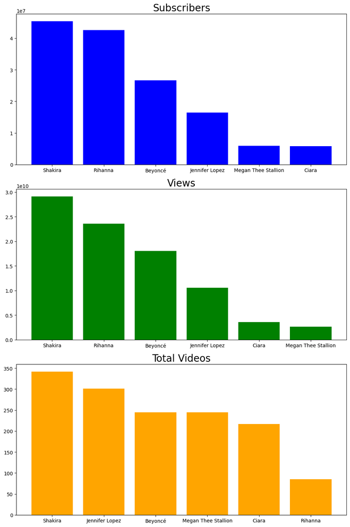

```python
import matplotlib.pyplot as plt

# Sort the DataFrame by 'Subscribers' in descending order
combined_female_pop_artist_channels_df_subscribers_sorted = combined_female_pop_artist_channels_df.sort_values(by='Subscribers', ascending=False)

# Plotting Subscribers in descending order
fig, axes = plt.subplots(nrows=3, ncols=1, figsize=(10, 15))

axes[0].bar(combined_female_pop_artist_channels_df_subscribers_sorted['Channel_name'],combined_female_pop_artist_channels_df_subscribers_sorted['Subscribers'], color='blue')
axes[0].set_title('Subscribers', fontsize=20)  # Adjust title font size as needed

# Sort the DataFrame by 'Views' in descending order
combined_female_pop_artist_channels_df_views_sorted = combined_female_pop_artist_channels_df.sort_values(by='Views', ascending=False)

# Plotting Views in descending order
axes[1].bar(combined_female_pop_artist_channels_df_views_sorted['Channel_name'], combined_female_pop_artist_channels_df_views_sorted['Views'], color='green')
axes[1].set_title('Views', fontsize=20)  # Adjust title font size as needed

# Sort the DataFrame by 'Total_videos' in descending ordercombined_female_pop_artist_channels_df
combined_female_pop_artist_channels_df_total_videos_sorted = combined_female_pop_artist_channels_df.sort_values(by='Total_videos', ascending=False)

# Plotting Total Videos in descending ordercombined_male_rnb_artist_channels_df
axes[2].bar(combined_female_pop_artist_channels_df_total_videos_sorted['Channel_name'], combined_female_pop_artist_channels_df_total_videos_sorted['Total_videos'], color='orange')
axes[2].set_title('Total Videos', fontsize=20)  # Adjust title font size as needed



# Adjust layout for better visibility
plt.tight_layout()

# Show the plot
plt.show()
```